# Solving the problem of Lead Generation and the concept of Lean Analytics

## What is the fuss all about?!

## In this post we will cover the basics of two concepts – lean analytics & lead generation.

#### _Lean Analytics_

Inspired by a blog post about a book I was reading, I came across the concept of Lean Analytics. *The Lean Analytics Cycle*, aims to help you create a sustainable way to pick metrics that matter by tying them to fundamental business problems, creating hypotheses you can test and driving change in the business from the learnings you identify. The concept is similar to *Lean Startup*, we continuously improve, iterate and check upon results, and decide what to do.  
The Lean Analytics Cycle is a simple four step iterative process.

### - Step1: Figure out what to improve.

### - Step2: Form the hypothesis.

### - Step3:Create the experiment

### - Step4: Measure and decide what to do

Step 2,3,4 are repeated continuously until we get the desired outcome. I will explain each step in detail as we dive into an experiment with lead generation.

#### _Lead Generation_

According to *hubspot*,

#### *Lead generation is the process of attracting and converting strangers and prospects into someone who has indicated interest in your company's product or service. Some examples of lead generators are job applications, blog posts, coupons, live events, and online content.*

### *"In simpler words, a good lead generation system in your organization will save you from being blocked/tagged as spam by customers!"*

Although people will click on your website’s link, see your product at a grocery store what is the possibility of making them buy it?

#### Lead Generation is that small window, that tiny gap using which you can make the customer pick your product at the store.

You attract strangers as visitors, you generate leads and successfully convert them into your customers, who(fingers crossed) will eventually become your promoters!

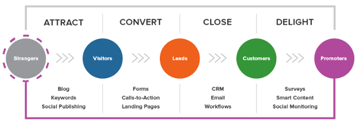

## Lets get to work already!

For our experiment, we have a beautiful website by Kayla dedicated to women’s healthy lifestyle, food and fitness.*(Awareness)* The blogger has lots of followers and she promises to email more tips, diet plans, recipes and exercises when people opt-in to do so using a subscribe button. *(Lead Generation)*

After a few emails of sending strategies, Kayla decides to host an online exercise session for all women and emails the same. *(Prospect)*. After a few free online sessions, she hosts a package of 12 sessions with a discount offer to all her prospects *(Sale)*!

### Step1: Figure out what to improve

The most crucial step is to decide what to improve, which is directly tied to the company’s KPIs and KRIs. Some examples can be to improve the number of visitors for a website, lower churn rate, increase conversion rate, getting more people to your restaurant etc. That one metric which will improve your KPIs, is critical for your business and will drive your profits for the next few months.

For our Kayla, it is to increase the number of people who visit her website and opt-in for her emails so that they can be the future customers to her online sessions.

### Step2: Form a hypothesis

This step is all about collecting the data(exploratory data analysis), understanding the existing data, understanding customer behaviour – what are they buying, from where do customers come, what type of products are they combining and buying, what are loyal customers buying etc. In case we don’t have the data, this step is also about collecting the data.

For our data set, lead_gen.csv we have information on number of visitors from different channels and if they subscribed to the emails.

### DataSet Explained

Lets read the dataset and see what columns it contains.

```python
#pandas for data manipulation and analysis
import pandas as pd

#visualization library
from matplotlib import pyplot as plt
#statistical data visualizaton library makes matplotlib look prettier
import seaborn as sns
```

```python
#Read the csv file.
df = pd.read_csv('../Lead_Generation/lead_gen.csv')
```

```python
df.head()
```

|  | source | returning | mobile | country | pages_viewed | lead |
| --- | --- | --- | --- | --- | --- | --- |
| 0 | Taboola | 1 | 1 | US | 2 | 0 |
| 1 | Taboola | 0 | 1 | US | 6 | 0 |
| 2 | Facebook | 0 | 0 | US | 2 | 0 |
| 3 | Taboola | 0 | 0 | US | 5 | 0 |
| 4 | Taboola | 0 | 0 | Canada | 5 | 0 |

```python
#Check if data has any missing values.
print(df.isnull().sum())
print(df.isna().sum())
```

```
source          0
returning       0
mobile          0
country         0
pages_viewed    0
lead            0
dtype: int64
source          0
returning       0
mobile          0
country         0
pages_viewed    0
lead            0
dtype: int64
```

**Dataset explained:**

- Source: Kayla hosted ads in different channels, the source using which they clicked on her site.
- Returning: Did they already visit her site?
- Mobile: What device did they use to visit her site? (Mobile?)
- Country: Which country are we getting hits on her website from
- Pages viewed: Number of pages, viewed by visitor in one session
- Lead: Did the visitor of the page subscribe to the emails?

As an example of hypothesis, we will measure which countries have the highest conversion rates

```python
#Mean of conversions in percentage
round(df.lead.mean()*100,2)
```

```
3.21
```

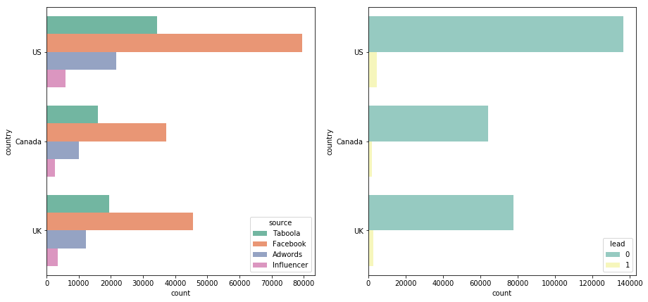

```python
fig, (ax1,ax2) = plt.subplots(1,2, figsize=(15,7))
sns.countplot(y = 'country',hue='source',data = df, orient='h',palette="Set2", ax =ax1)
sns.countplot(y = 'country',hue='lead',data = df, orient='h',palette="Set3", ax =ax2)
plt.show()
plt.tight_layout()
```

#### *Our Observations till now*

- The percentage of people subsrcibing is 3.2%
- Most of the ads clicks are through Facebook
- And the maximum click rate as well as leads are from the US.

```python
#A better version of plotting the data and get insights

def conversion_rate_plots(axis_segment):
    fig, (ax1,ax2) = plt.subplots(1,2, figsize=(15,5), sharey = False)

    #We plot the distribution on the left & the conversion rate for the same on the right
    sns.countplot(x = axis_segment , data = df, ax =ax1)
    sns.barplot(x = axis_segment, y = 'lead', data = df, ax =ax2)

    plt.suptitle('Conversion rate by {}'.format(axis_segment))
    plt.show()
```

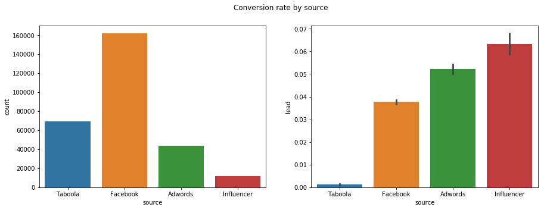

```python
conversion_rate_plots(axis_segment = 'source')
```

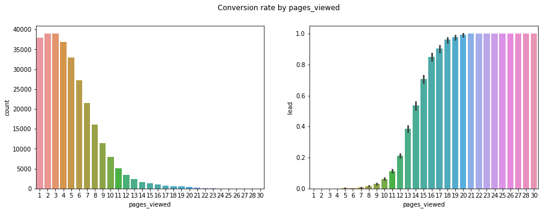

```python
conversion_rate_plots(axis_segment = 'pages_viewed')
```

Based on above observation as pages viewed increases, people are subscribing. - we shall test this.

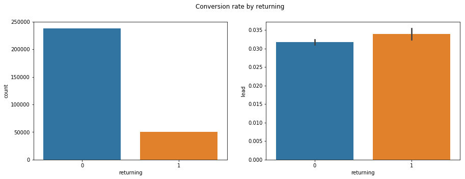

```python
conversion_rate_plots(axis_segment = 'returning')
```

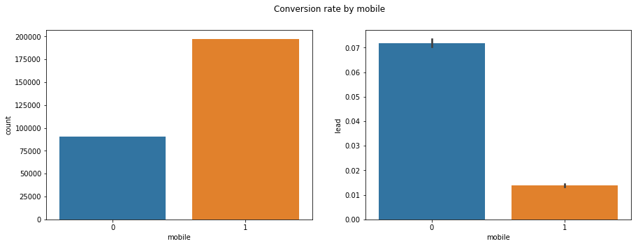

```python
conversion_rate_plots(axis_segment = 'mobile')
```

from the above graph, we notice that number of people visiting site from tablet/mobile is more than desktop but, the subscribers is more from desktop.

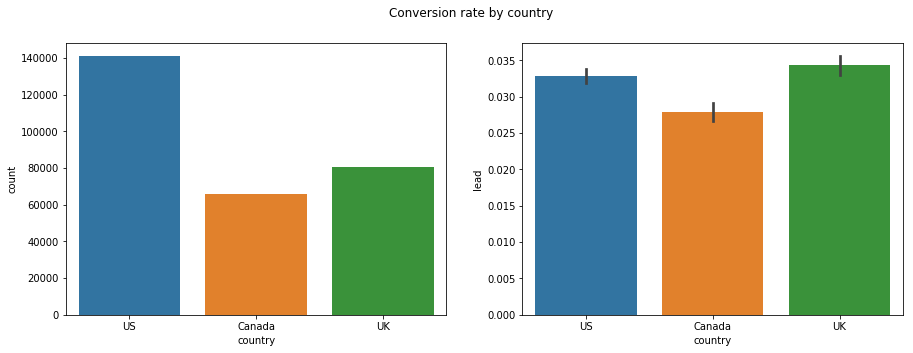

```python
conversion_rate_plots(axis_segment = 'country')
```

## Step3:Create the experiment

### "*Find out if **WHO** will do **WHAT** because **WHY** enough to improve KPI by the Target you've defined.*"

In this step, based on our target audience, our KPIs and what we want the outcome to be we design the experiment. Here we also take some time to document the outcomes.

Based on the set parameters we run the experiment.

### in our case, we will build a model to predict conversion rates based on visitor information.

```python
#train_test_split is to random train & test data sets
from sklearn.model_selection import train_test_split

from sklearn.ensemble import GradientBoostingClassifier, partial_dependence
from sklearn.linear_model import LogisticRegression

from sklearn.metrics import roc_auc_score
```

```python
# Analytical Base table
#remove the 'lead' column from this dummy data set.

abt = pd.get_dummies(df)

abt.head()
```

|  | returning | mobile | pages_viewed | lead | source_Adwords | source_Facebook | source_Influencer | source_Taboola | country_Canada | country_UK | country_US |
| --- | --- | --- | --- | --- | --- | --- | --- | --- | --- | --- | --- |
| 0 | 1 | 1 | 2 | 0 | 0 | 0 | 0 | 1 | 0 | 0 | 1 |
| 1 | 0 | 1 | 6 | 0 | 0 | 0 | 0 | 1 | 0 | 0 | 1 |
| 2 | 0 | 0 | 2 | 0 | 0 | 1 | 0 | 0 | 0 | 0 | 1 |
| 3 | 0 | 0 | 5 | 0 | 0 | 0 | 0 | 1 | 0 | 0 | 1 |
| 4 | 0 | 0 | 5 | 0 | 0 | 0 | 0 | 1 | 1 | 0 | 0 |

```python
#seperating input features(X) and target variable(y)
y = abt.lead
X = abt.drop('lead',axis = 1)

#Splitting into test & train datasets
X_train, X_test, y_train,y_test = train_test_split(X,y,test_size = 0.2, random_state = 123)
```

At this point, I think it is a good time to stop and go through these links to understand what Gradient Boosting and Decision trees is all about.

- http://www.cse.chalmers.se/~richajo/dit865/files/gb_explainer.pdf
- https://towardsdatascience.com/ensemble-methods-in-machine-learning-what-are-they-and-why-use-them-68ec3f9fef5f

### *don't ever use an algorithm because someone else used it. Don't make it a black box! Also, don't select an algorithm because of your hunch*

Over different projects we shall do in Pratisamvid, I shall try to cover most of the algorithms.

```python
gbm = GradientBoostingClassifier()

#Here, finally we try to fit the tree.
gbm.fit(X_train,y_train)
```

```
GradientBoostingClassifier(criterion='friedman_mse', init=None,
              learning_rate=0.1, loss='deviance', max_depth=3,
              max_features=None, max_leaf_nodes=None,
              min_impurity_decrease=0.0, min_impurity_split=None,
              min_samples_leaf=1, min_samples_split=2,
              min_weight_fraction_leaf=0.0, n_estimators=100,
              n_iter_no_change=None, presort='auto', random_state=None,
              subsample=1.0, tol=0.0001, validation_fraction=0.1,
              verbose=0, warm_start=False)
```

Next we calculate the *Area under ROC Curve (AUROC)*

```python
pred = gbm.predict_proba(X_test)

#only choosing the positive class
pred = [p[1] for p in pred]

#Display AUROC
roc_auc_score(y_test,pred)
```

```
0.9816511748289412
```

A high AUROC implies that the model is predicitve. Now, let us see some feature importances

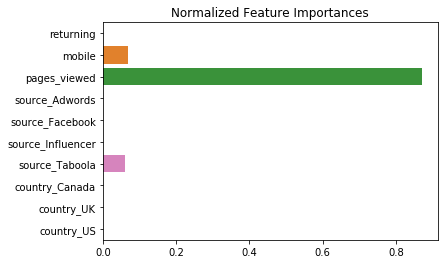

```python
plt.title('Normalized Feature Importances')
sns.barplot(y=X.columns, x=gbm.feature_importances_)
plt.show()
```

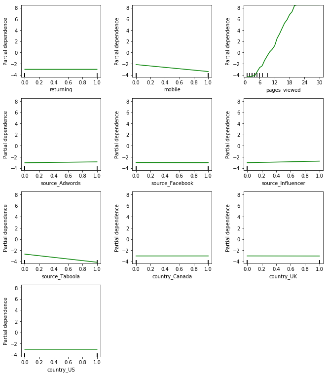

```python
#partial dependence plots

partial_dependence.plot_partial_dependence(gbm,X=X_train,features = range(len(X.columns)), feature_names = X.columns, figsize = (10,18))

plt.show()
```

## Step4: Measure and decide what to do

- What is influencing user behavior? From the insights above, it is paged viewed. So maybe if we can get more pages viewed, we can increase number of subscribers? How would we do that? Once we do that we should run our algorithms again (go back to Step 2 and repeat from there)
- Also, which country is not responding to ads? Which country is? Where can we invest more on ad campagins, where should we stop?

This is what step4 is all about. Measuring what we did, and going back to step2 and repeating the process till we get the desired results.